# Denetimli İstatistiksel Öğrenme Ara Sınav

## Hataların Sabit Varyanslılığı

BP test hipotezleri:

Ho: Hatalar sabit varyanslıdır.

Ha: Hatalar sabit varyanslı değildir.

```r
bptest(wage ~year+ age + maritl + education + health + health_ins, data=train)
```

```
##
##  studentized Breusch-Pagan test
##
## data:  wage ~ year + age + maritl + education + health + health_ins
## BP = 105.46, df = 12, p-value < 2.2e-16
```

P değeri 0.05’ten küçük olduğu için %95 güvenle hatalar sabit varyanslıdır hipotezi reddedilebilir.

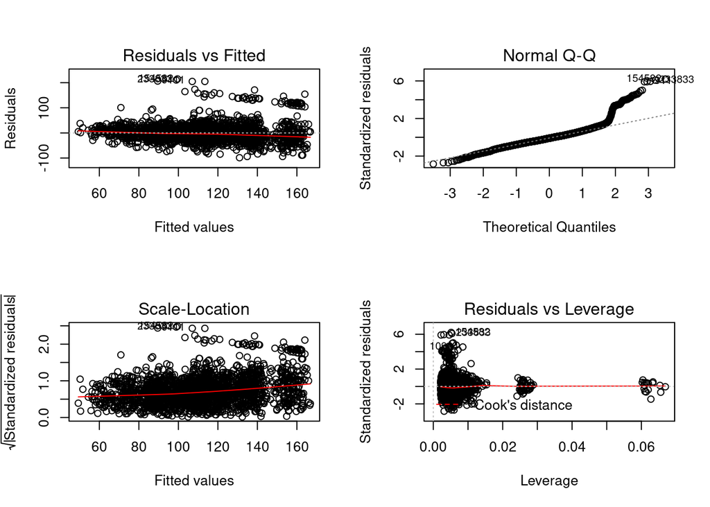

Residuallar ile Fitted Valuelar arasındaki grafik incelendiğinde bir daralma gözlemlenmemiştir. Hataların sabit varyanslı olmadığı görülmektedir. Ayrıca uç değerlerin modeli baskıladığı da dikkat çekmektedir. Uç değerlerin veri setinden çıkarılması mantıklı bir hareket olabilir.

## Uç Değer Analizi

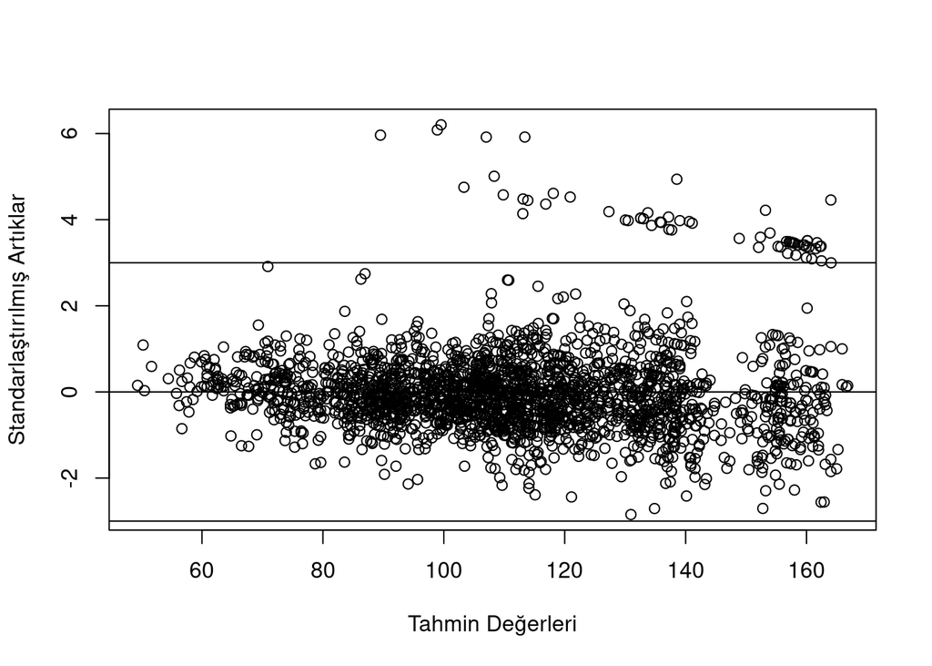

```r
standardized.residuals<-
  modelbest$residuals/sqrt(var(modelbest$residuals))

plot(modelbest$fitted.values,standardized.residuals, xlab = "Tahmin Değerleri", ylab = "Standarlaştırılmış Artıklar")
abline(h=0)
abline(h=-3)
abline(h=3)
```

Tahmin değerleri ile standartlaştırılmış artıklar grafiği incelendiğinde standartlaştırılmış artık değeri -3’den küçük, 3’den büyük olan 62 adet artık saptanmıştır. Bu 62 değer, uç değer olarak yorumlanmıştır.

## Kaldıraç Analizi

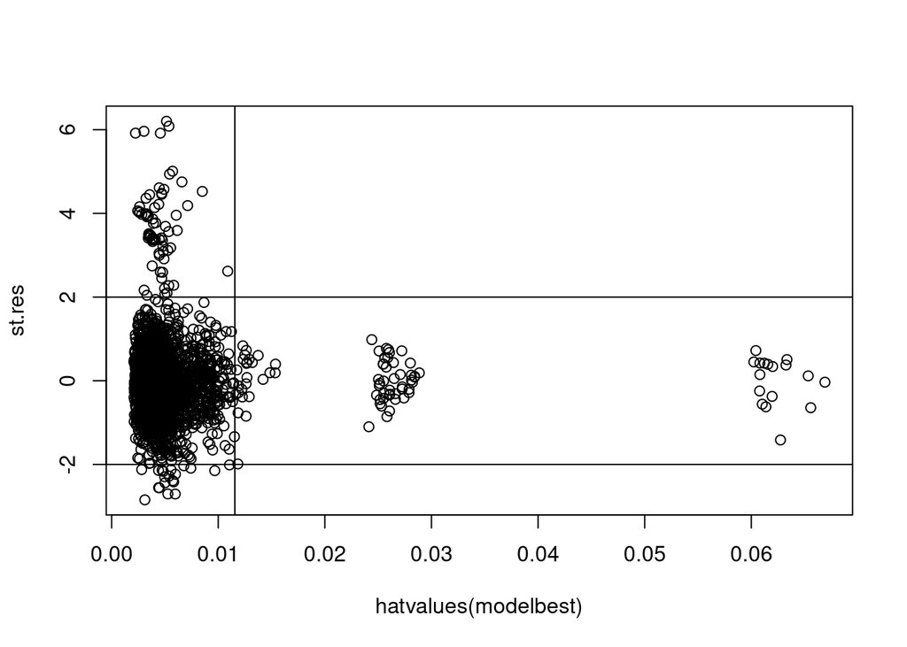

```r
st.res <- modelbest$residuals/sd(modelbest$residuals) #modelin hatasını bulmak gerekir, degrees of freedom hatası yüzünden
plot(hatvalues(modelbest),st.res)
abline(h=c(-2,2),v=2*mean(hatvalues(modelbest)))
```

Hat değerleri ile standardized residuals arasındaki grafik incelendiğinde hiç kötü kaldıraç olmadığı gözlemlenmiştir. İyi kaldıraç sayısı ise 86 olarak saptanmıştır.

## Cook’s Distance

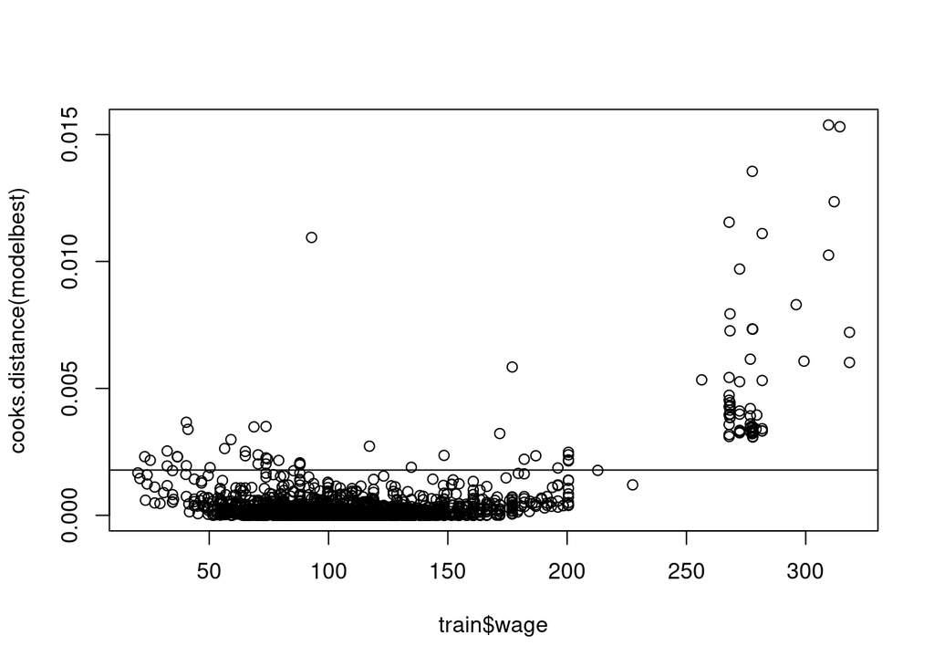

```r
plot(train$wage,cooks.distance(modelbest))
abline(h=4/(length(train$wage)-6))
```

Cook’s Discance grafiği incelendiğinde 101 adet etkin gözlem olduğu saptanmıştır. Grafikte outlier olarak saptanan gözlemlerin hepsinin etkin gözlem olduğu fark edilmiştir. Demek ki aykırı gözlemler modelin eğimine çok etki yapıyor. Model geliştirmede bu konuda değişiklikler yapmak mantıklı olabilir.

## Model Geliştirme

Tanımlayıcı istatistik kısmında düşünülen level birleştirme işlemi rapor dışında veri setine uygulanmış ancak birleştirme sonrasında da Married dışındaki diğer level’ların anlamlı olmadığı fark edilmiştir. Bu sebeple bu değişiklik rapora eklenmemiştir. Kurulan modellerin hepsinde medeni durumu belirten factorun sadece married level’ının anlamlı olduğu saptanmıştır. Bu sebeple model geliştirme yöntemine bu factorun seviyesini ikiye düşürerek(Married 1, değil 0) devam edilecektir.

```r
train %<>%  mutate(maritl = ifelse(train$maritl == "2. Married", 1, 0))
train$maritl <- as.factor(train$maritl)
str(train)
```

```
## 'data.frame':    2250 obs. of  10 variables:
##  $ year      : int  2004 2008 2005 2006 2009 2007 2004 2008 2009 2004 ...
##  $ age       : int  54 58 48 43 54 36 49 24 47 47 ...
##  $ maritl    : Factor w/ 2 levels "0","1": 1 1 2 1 2 2 2 1 1 2 ...
##  $ race      : Factor w/ 4 levels "1. White","2. Black",..: 1 1 1 2 3 1 1 1 1 1 ...
##  $ education : Factor w/ 5 levels "1. < HS Grad",..: 4 1 4 5 3 1 2 2 2 4 ...
##  $ jobclass  : Factor w/ 2 levels "1. Industrial",..: 1 1 2 1 2 1 2 1 1 1 ...
##  $ health    : Factor w/ 2 levels "1. <=Good","2. >=Very Good": 2 2 2 2 2 1 2 2 1 2 ...
##  $ health_ins: Factor w/ 2 levels "1. Yes","2. No": 2 1 1 1 1 2 1 2 1 2 ...
##  $ logwage   : num  4.48 4.6 5.1 4.79 4.9 ...
##  $ wage      : num  88 99.7 163.5 119.7 134.7 ...
```

Bu kısma kadar yapılan değişikliklerin hiçbiri modelin varsayımları sağlamasına yardımcı olmamıştır. Bağımlı değişkenin normal dağılmıyor oluşu buna sebep olabilir.Bu sebeple bağımlı değişkenin normal dağılmasını sağlamak modeli iyileştirmek adına yapılabilecek ilk adım olabilir. bestNormalize paketi kullanılarak Y’nin normal dağılması sağlanmaya çalışılacaktır.

```r
bestNormalize(test$wage)
```

```
## Best Normalizing transformation with 750 Observations
##  Estimated Normality Statistics (Pearson P / df, lower => more normal):
##  - arcsinh(x): 1.293
##  - Box-Cox: 1.2752
##  - Center+scale: 2.0453
##  - Exp(x): 78.7332
##  - Log_b(x+a): 1.293
##  - orderNorm (ORQ): 1.278
##  - sqrt(x + a): 1.4146
##  - Yeo-Johnson: 1.2752
## Estimation method: Out-of-sample via CV with 10 folds and 5 repeats
##
## Based off these, bestNormalize chose:
## Standardized Box Cox Transformation with 750 nonmissing obs.:
##  Estimated statistics:
##  - lambda = 0.08115032
##  - mean (before standardization) = 5.670729
##  - sd (before standardization) = 0.4939055
```

bestNormalize paketi bağımlı değişkenin normalleşmesi için aşağıdaki dönüşümleri önermiştir: boxcox, yeo-johnson, arcsinh. Buna ek olarak tanımlayıcı istatistik kısmında logaritması alınan wage değişkenin sola çarpık olduğu gözlemlenmişti. Bu sebeple bestNormalize’ın önermelerine ek olarak bir de logaritması alınmış wage’in karekökü alınmıştır. Her dönüşümü sonrası normallik sınamaları yapılmıştır.

**Box Cox Dönüşümü**

```r
boxwage <- boxcox(train$wage)
ad.test(boxwage$x.t)
```

```
##
##  Anderson-Darling normality test
##
## data:  boxwage$x.t
## A = 9.9373, p-value < 2.2e-16
```

```r
shapiro.test(boxwage$x.t)
```

```
##
##  Shapiro-Wilk normality test
##
## data:  boxwage$x.t
## W = 0.97604, p-value < 2.2e-16
```

İki testin de hipotezleri aşağıdaki gibidir:

Ho : Dönüştürülmüş değişken normal dağılmaktadır.  
Ha : Dönüştürülmüş değişken normal dağılmamaktadır.

P değeri 0.05’ten küçük olduğu için %95 güvenle değişkenin normal dağıldığı hipotezini reddetmek için yeterli kanıt vardır.

**Yeo Johnson Dönüşümü**

```r
yeowage <- yeojohnson(train$wage)
ad.test(yeowage$x.t)
```

```
##
##  Anderson-Darling normality test
##
## data:  yeowage$x.t
## A = 9.8291, p-value < 2.2e-16
```

```r
shapiro.test(yeowage$x.t)
```

```
##
##  Shapiro-Wilk normality test
##
## data:  yeowage$x.t
## W = 0.9763, p-value < 2.2e-16
```

İki testin de hipotezleri aşağıdaki gibidir:

Ho : Dönüştürülmüş değişken normal dağılmaktadır.  
Ha : Dönüştürülmüş değişken normal dağılmamaktadır.

P değeri 0.05’ten küçük olduğu için %95 güvenle değişkenin normal dağıldığı hipotezini reddetmek için yeterli kanıt vardır.

**arcsinh dönüşümü**

```r
arcwage <- arcsinh_x(train$wage)
ad.test(arcwage$x.t)
```

```
##
##  Anderson-Darling normality test
##
## data:  arcwage$x.t
## A = 9.792, p-value < 2.2e-16
```

```r
shapiro.test(arcwage$x.t)
```

```
##
##  Shapiro-Wilk normality test
##
## data:  arcwage$x.t
## W = 0.97547, p-value < 2.2e-16
```

İki testin de hipotezleri aşağıdaki gibidir:

Ho : Dönüştürülmüş değişken normal dağılmaktadır.  
Ha : Dönüştürülmüş değişken normal dağılmamaktadır.

P değeri 0.05’ten küçük olduğu için %95 güvenle değişkenin normal dağıldığı hipotezini reddetmek için yeterli kanıt vardır.

**sqrt(log(x)) Dönüşümü**

```r
donusuwage <- sqrt(log(train$wage))
ad.test(donusuwage)
```

```
##
##  Anderson-Darling normality test
##
## data:  donusuwage
## A = 10.674, p-value < 2.2e-16
```

```r
shapiro.test(donusuwage)
```

```
##
##  Shapiro-Wilk normality test
##
## data:  donusuwage
## W = 0.97099, p-value < 2.2e-16
```

İki testin de hipotezleri aşağıdaki gibidir:

Ho : Dönüştürülmüş değişken normal dağılmaktadır.  
Ha : Dönüştürülmüş değişken normal dağılmamaktadır.

P değeri 0.05’ten küçük olduğu için %95 güvenle değişkenin normal dağıldığı hipotezini reddetmek için yeterli kanıt vardır.

Önerilen hiçbir dönüşüm Y’nin normalleşmesini sağlamamıştır. Tanımlayıcı istatistikler incelendiği kısımda wage değişkeninin çift tepeli olduğu ve aykırı gözlemlerin çok olduğu fark edilmişti. Bu sebeple ikinci tepeye sebep olan aykırı gözlemlerin veri setinden çıkarılması amaçlanmaktadır. Uç değerlerin bağımlı değişkenden çıkarılmasının normalleştirmeyi sağlayabileceği düşünülmektedir.

**Aykırı Gözlemlerin IQR Yöntemi ile Çıkarılması**

```r
quartiles <- quantile(train$wage, probs=c(.25, .75), na.rm = FALSE)
IQR <- IQR(train$wage)

Lower <- quartiles[1] - 1.5*IQR
Upper <- quartiles[2] + 1.5*IQR

train_no_outlier <- subset(train, train$wage > Lower & train$wage < Upper)
```

Bağımlı değişkene göre aykırı gözlem olarak saptanan gözlemler veri setinden çıkarıldıktan sonra tekrar hipotez testleri yapılarak normallik sınaması yapılmak istenilmiştir.

```r
ad.test(train_no_outlier$wage)
```

```
##
##  Anderson-Darling normality test
##
## data:  train_no_outlier$wage
## A = 5.1129, p-value = 1.236e-12
```

```r
shapiro.test(train_no_outlier$wage)
```

```
##
##  Shapiro-Wilk normality test
##
## data:  train_no_outlier$wage
## W = 0.99228, p-value = 2.758e-09
```

İki testin de hipotezleri aşağıdaki gibidir:

Ho : Dönüştürülmüş değişken normal dağılmaktadır.  
Ha : Dönüştürülmüş değişken normal dağılmamaktadır.

P değeri 0.05’ten küçük olduğu için %95 güvenle değişkenin normal dağıldığı hipotezini reddetmek için yeterli kanıt vardır.

Uç değerler veri setinden çıkarıldıktan sonra da normalleştirme sağlanamamıştır; ancak biraz olsun yaklaşılmıştır. Histogram grafiği de bu bilgiyi desteklemiştir.

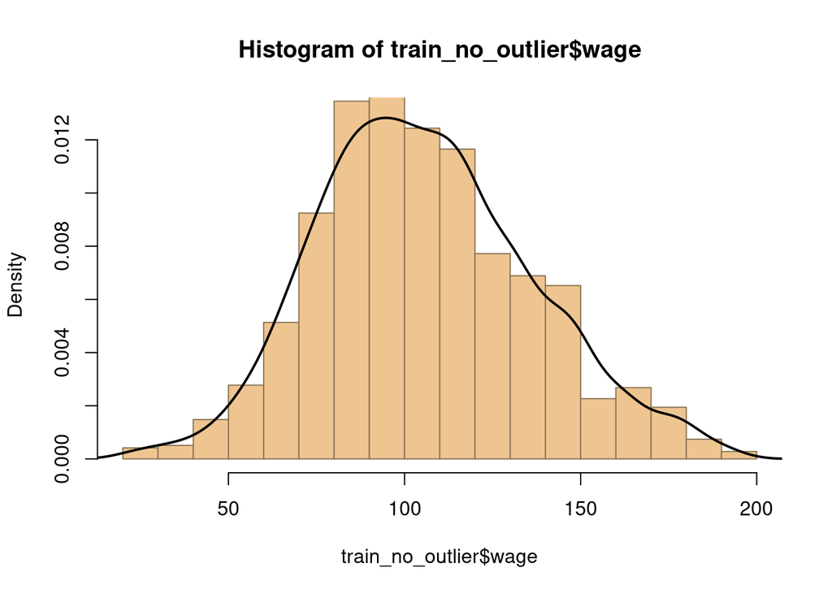

```r
fun <- dnorm(train_no_outlier$wage, mean = mean(train_no_outlier$wage), sd = sd(train_no_outlier$wage))

hist(train_no_outlier$wage, col="burlywood2",
     border="burlywood4", probability = T, ylim = c(0, max(fun)))

lines(density(train_no_outlier$wage), col = 9, lwd = 2)
```

Histogram grafiği incelendiğinde normale oldukça yakın bir dağılım görülmektedir. Neden normal olmadığı ile ilgili daha iyi bir bilgi sahibi olabilmek amacıyla çarpıklık değerinin incelenmesi istenilmiştir.

```r
skewness(train_no_outlier$wage)
```

```
## [1] 0.2703152
```

skewness değeri 0’dan büyük olduğu için sağa çarpık olduğu saptanmıştır. Uç değerlerin çıkarıldığı bağımlı değişkenin normalliğinin sağlanması için bestNormalize paketi kullanılacaktır.

```r
bestNormalize(train_no_outlier$wage)
```

```
## Best Normalizing transformation with 2163 Observations
##  Estimated Normality Statistics (Pearson P / df, lower => more normal):
##  - arcsinh(x): 1.801
##  - Box-Cox: 1.4356
##  - Center+scale: 1.5598
##  - Exp(x): 240.5742
##  - Log_b(x+a): 1.8161
##  - orderNorm (ORQ): 1.2729
##  - sqrt(x + a): 1.3781
##  - Yeo-Johnson: 1.4318
## Estimation method: Out-of-sample via CV with 10 folds and 5 repeats
##
## Based off these, bestNormalize chose:
## orderNorm Transformation with 2163 nonmissing obs and ties
##  - 396 unique values
##  - Original quantiles:
##      0%     25%     50%     75%    100%
##  20.934  84.046 103.902 127.116 193.453
```

bestNormalize paketi aykırı gözlemler çıkarılmış bağımlı değişkenleri normalleştirmek için en iyi yöntemin orderNorm olduğu saptamıştır. Ordered Quantile (ORQ) normalleştirme dönüşümü, bir vektörün değerlerinin yüzdelik dilimlerine eşlendiği ve daha sonra normal dağılımın aynı yüzdelik dilimine eşlendiği sıralama tabanlı bir prosedürdür. Bağların varlığı olmadan, bu esasen dönüşümün düzgün bir dağılıma yol açmasını garanti eder.

```r
orderwage <- orderNorm(train_no_outlier$wage)

ad.test(orderwage$x.t)
```

```
##
##  Anderson-Darling normality test
##
## data:  orderwage$x.t
## A = 0.39607, p-value = 0.37
```

```r
shapiro.test(orderwage$x.t)
```

```
##
##  Shapiro-Wilk normality test
##
## data:  orderwage$x.t
## W = 0.99954, p-value = 0.9101
```

İki testin de hipotezleri aşağıdaki gibidir:

Ho : Dönüştürülmüş değişken normal dağılmaktadır.  
Ha : Dönüştürülmüş değişken normal dağılmamaktadır.

P değeri 0.05’ten büyük olduğu için %95 güvenle değişkenin normal dağıldığı hipotezi reddedilemez.

Anderson-Darling ve Shapiro-Wilk normallik testlerinin sonucuna göre bağımlı değişkenin normalliği sağlanmıştır. Bu sebeple bu dönüşüm yapılmış bağımlı değişken ile tekrar model kurulmak istenilmiştir.

```r
trainnormal <- train_no_outlier
trainnormal$wage <- orderwage$x.t

modelout <- lm(wage ~ year + age + maritl + education + health + health_ins, data = trainnormal)
summary(modelout)
```

```
##
## Call:
## lm(formula = wage ~ year + age + maritl + education + health +
##     health_ins, data = trainnormal)
##
## Residuals:
##      Min       1Q   Median       3Q      Max
## -3.11645 -0.50110  0.00687  0.50917  3.10198
##
## Coefficients:
##                               Estimate Std. Error t value Pr(>|t|)
## (Intercept)                 -92.476693  16.834603  -5.493 4.41e-08 ***
## year                          0.045560   0.008394   5.427 6.36e-08 ***
## age                           0.007606   0.001580   4.813 1.59e-06 ***
## maritl1                       0.426988   0.038784  11.009  < 2e-16 ***
## education2. HS Grad           0.239869   0.062925   3.812 0.000142 ***
## education3. Some College      0.583682   0.067203   8.685  < 2e-16 ***
## education4. College Grad      0.855507   0.067121  12.746  < 2e-16 ***
## education5. Advanced Degree   1.181469   0.075532  15.642  < 2e-16 ***
## health2. >=Very Good          0.180848   0.038396   4.710 2.63e-06 ***
## health_ins2. No              -0.638566   0.038307 -16.670  < 2e-16 ***
## ---
## Signif. codes:  0 '***' 0.001 '**' 0.01 '*' 0.05 '.' 0.1 ' ' 1
##
## Residual standard error: 0.7883 on 2153 degrees of freedom
## Multiple R-squared:  0.3804, Adjusted R-squared:  0.3778
## F-statistic: 146.9 on 9 and 2153 DF,  p-value: < 2.2e-16
```

Aykırı gözlemlerin çıkarılması ve medeni durum faktörünün seviyesinin ikiye düşürülmesi ve bağımlı değişkenin normalliğinin sağlanması sonrasında oluşturulan yeni nodelin çıktısı incelendiğinde; yeni model geçerli olmuş, bütün bağımsız değişkenler anlamlı olarak görülmüştür.

Rapor dışında yapılan denemelerde tek sayısal değişken olan Age değişkeninin ilk önce karesi, ardından küpü alınmıştır. Bu iki değişikliğin de modeli iyileştirdiği fark edilmiştir. Bu sebeple bu değişiklikler de modele eklenecektir.

```r
train_deneme <- trainnormal
train_deneme[11] <- (train_no_outlier$age)^2
train_deneme[12] <- (train_no_outlier$age)^3

modeldeneme <- lm(wage ~ year + age + V11 + V12 + maritl + education + health + health_ins, data= train_deneme)
summary(modeldeneme)
```

```
##
## Call:
## lm(formula = wage ~ year + age + V11 + V12 + maritl + education +
##     health + health_ins, data = train_deneme)
##
## Residuals:
##     Min      1Q  Median      3Q     Max
## -3.1945 -0.4905  0.0188  0.5112  2.9585
##
## Coefficients:
##                               Estimate Std. Error t value Pr(>|t|)
## (Intercept)                 -9.940e+01  1.654e+01  -6.009 2.19e-09 ***
## year                         4.747e-02  8.236e-03   5.764 9.39e-09 ***
## age                          2.008e-01  3.618e-02   5.549 3.22e-08 ***
## V11                         -3.539e-03  8.178e-04  -4.328 1.57e-05 ***
## V12                          1.928e-05  5.911e-06   3.262 0.001125 **
## maritl1                      3.318e-01  3.937e-02   8.428  < 2e-16 ***
## education2. HS Grad          2.405e-01  6.173e-02   3.896 0.000101 ***
## education3. Some College     5.859e-01  6.591e-02   8.889  < 2e-16 ***
## education4. College Grad     8.405e-01  6.584e-02  12.767  < 2e-16 ***
## education5. Advanced Degree  1.161e+00  7.410e-02  15.666  < 2e-16 ***
## health2. >=Very Good         1.620e-01  3.770e-02   4.296 1.81e-05 ***
## health_ins2. No             -5.884e-01  3.795e-02 -15.503  < 2e-16 ***
## ---
## Signif. codes:  0 '***' 0.001 '**' 0.01 '*' 0.05 '.' 0.1 ' ' 1
##
## Residual standard error: 0.773 on 2151 degrees of freedom
## Multiple R-squared:  0.4048, Adjusted R-squared:  0.4018
## F-statistic:   133 on 11 and 2151 DF,  p-value: < 2.2e-16
```

Yapılan tüm bu işlemler sonrasında eklenen değişkenlerin hepsi anlamlıdır. Buna ek olarak Rsquare ve Adj.Rsquare değerlerinde %7lik bir açıklayıcılık artışı gözlemlenmiştir. Yeni varsayım kontrolleri sırasında çıkarılabilecek yeni aykırı gözlemler(eğer varsa) sonrasında modelde biraz daha gelişme sağlanabilir.

## Geliştirilen Model Varsayım Kontrolü

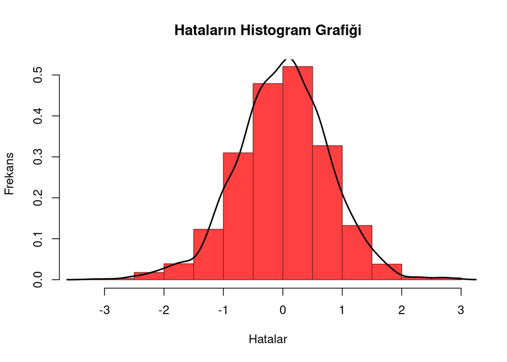

```r
fun <- dnorm(modeldeneme$residuals, mean = mean(modeldeneme$residuals), sd = sd(modeldeneme$residuals))

hist(modeldeneme$residuals,col="brown1",
     border="brown4", ylab = "Frekans", xlab = "Hatalar", main = "Hataların Histogram Grafiği", probability = T, ylim = c(0, max(fun)))


lines(density(modeldeneme$residuals), col = 1, lwd = 2)
```

Hataların histogram grafiği incelendiğinde normale oldukça yakın bir grafik görülmektedir. İki taraftaki kuyruklar da uzun olduğu için skewness değerine bakmak daha sağlıklı bir yorum yapılmasını sağlayacaktır.

```r
skewness(modeldeneme$residuals)
```

```
## [1] -0.1238418
```

Hataların skewness değeri -0.1 çıkmıştır. Normale oldukça yaklaştığı gözlemlenmiştir. Yine de hipotez testi ile kesin bir yargıya varılmak istenilmiştir.

```r
shapiro.test(modeldeneme$residuals)
```

```
##
##  Shapiro-Wilk normality test
##
## data:  modeldeneme$residuals
## W = 0.99592, p-value = 1.31e-05
```

```r
ad.test(modeldeneme$residuals)
```

```
##
##  Anderson-Darling normality test
##
## data:  modeldeneme$residuals
## A = 1.3214, p-value = 0.001989
```

```r
lillie.test(modeldeneme$residuals)
```

```
##
##  Lilliefors (Kolmogorov-Smirnov) normality test
##
## data:  modeldeneme$residuals
## D = 0.018278, p-value = 0.09056
```

Normal dağılana kadar uygulanan sayıdaki( :) ) normallik testlerinin hipotezleri aşağıdaki gibidir:

Ho : Hatalar normal dağılmaktadır.  
Ha : Hatalar normal dağılmamaktadır.

Lilliefors normallik testine göre p değeri 0.05’ten büyük olduğu için %95 güvenle değişkenin normal dağıldığı hipotezi reddedilemez.

## Hataların Sabit Varyanslılığı

```r
bptest(wage ~ year + age + V11 + V12 + maritl + education + health + health_ins, data= train_deneme)
```

```
##
##  studentized Breusch-Pagan test
##
## data:  wage ~ year + age + V11 + V12 + maritl + education + health +     health_ins
## BP = 64.96, df = 11, p-value = 1.096e-09
```

P-value 0.05’ten küçük olduğu için %95 güvenle hatalar serbest varyanslıdır hipotezi reddedilebilir.

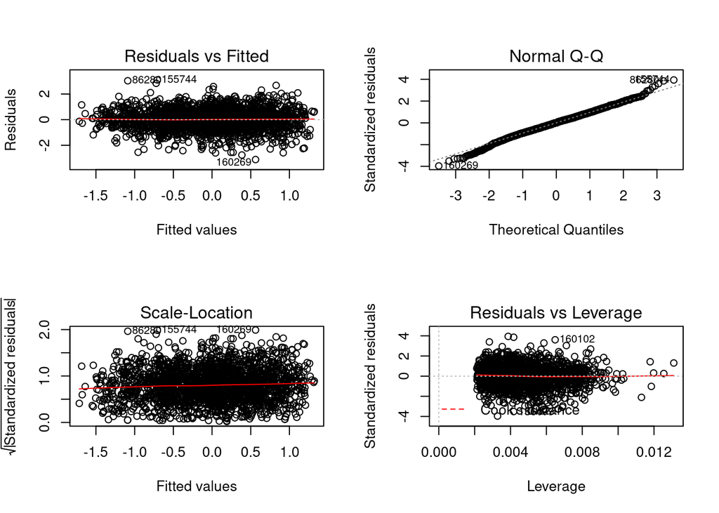

```r
par(mfrow = c(2,2))
plot(modelout)
```

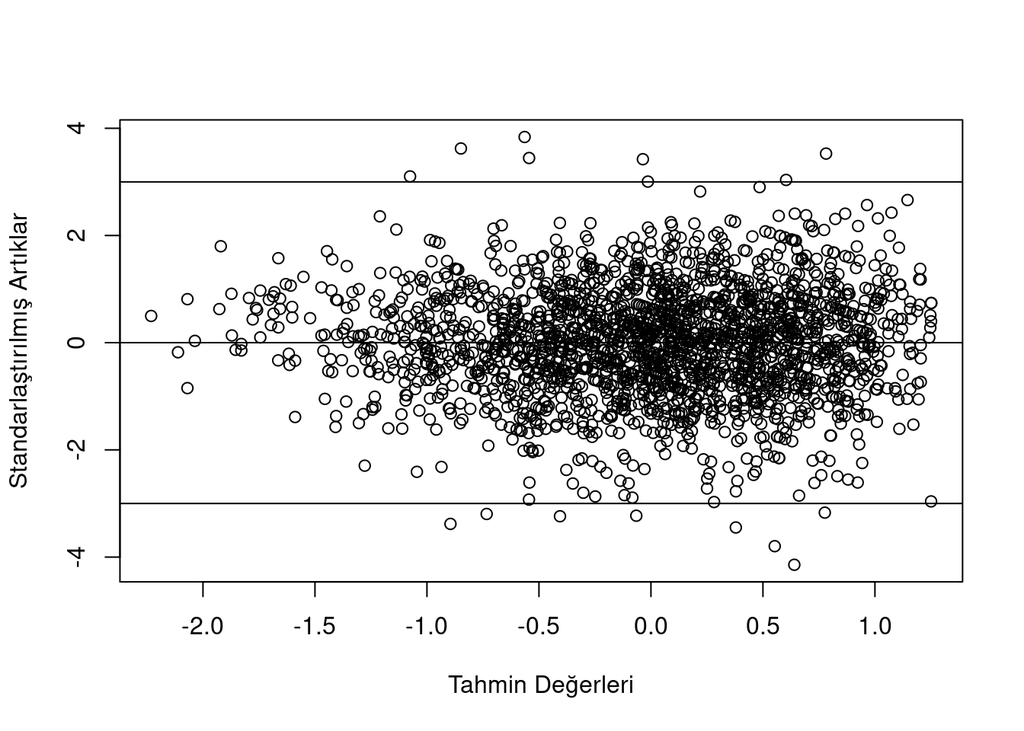

```r
standardized.residuals<-
  modeldeneme$residuals/sqrt(var(modeldeneme$residuals))

plot(modeldeneme$fitted.values,standardized.residuals, xlab = "Tahmin Değerleri", ylab = "Standarlaştırılmış Artıklar")
abline(h=0)
abline(h=-3)
abline(h=3)
```

```r
train.out.out <- train_deneme[-c(which(abs(standardized.residuals)>3)),]

modeloutout <- lm(wage ~year+ age + maritl + V11 + V12 + education + health + health_ins, data= train.out.out)

summary(modeloutout)
```

```
##
## Call:
## lm(formula = wage ~ year + age + maritl + V11 + V12 + education +
##     health + health_ins, data = train.out.out)
##
## Residuals:
##      Min       1Q   Median       3Q      Max
## -2.29348 -0.48818  0.02255  0.50272  2.20226
##
## Coefficients:
##                               Estimate Std. Error t value Pr(>|t|)
## (Intercept)                 -9.495e+01  1.595e+01  -5.952 3.08e-09 ***
## year                         4.523e-02  7.943e-03   5.694 1.41e-08 ***
## age                          2.041e-01  3.478e-02   5.867 5.13e-09 ***
## maritl1                      3.282e-01  3.795e-02   8.649  < 2e-16 ***
## V11                         -3.599e-03  7.860e-04  -4.579 4.94e-06 ***
## V12                          1.964e-05  5.680e-06   3.457 0.000558 ***
## education2. HS Grad          2.327e-01  5.944e-02   3.914 9.35e-05 ***
## education3. Some College     5.811e-01  6.355e-02   9.143  < 2e-16 ***
## education4. College Grad     8.492e-01  6.342e-02  13.390  < 2e-16 ***
## education5. Advanced Degree  1.182e+00  7.138e-02  16.566  < 2e-16 ***
## health2. >=Very Good         1.496e-01  3.631e-02   4.122 3.91e-05 ***
## health_ins2. No             -5.862e-01  3.665e-02 -15.997  < 2e-16 ***
## ---
## Signif. codes:  0 '***' 0.001 '**' 0.01 '*' 0.05 '.' 0.1 ' ' 1
##
## Residual standard error: 0.7413 on 2135 degrees of freedom
## Multiple R-squared:  0.4285, Adjusted R-squared:  0.4256
## F-statistic: 145.5 on 11 and 2135 DF,  p-value: < 2.2e-16
```

Artıklara göre uç değer olarak saptanan gözlemlerin veri setinden çıkarılmasıyla oluşan modelin çıktısı incelendiğinde; modelin ve modelde yer alan bütün bağımsız değişkenlerin anlamlı olduğu saptanmıştır. Modelin Rsquare ve Adj.Rsquare değerlerinde yaklşık olarak %2’lik bir artış sağlanmıştır. Varsayımların sağlanıp sağlanmadığı bu sefer yalnızca hipotez testleri ile test edilmek istenilmiştir.

**Hataların Normal Dağılması**

```r
shapiro.test(modeloutout$residuals)
```

```
##
##  Shapiro-Wilk normality test
##
## data:  modeloutout$residuals
## W = 0.99781, p-value = 0.004631
```

```r
ad.test(modeloutout$residuals)
```

```
##
##  Anderson-Darling normality test
##
## data:  modeloutout$residuals
## A = 0.53789, p-value = 0.1679
```

```r
lillie.test(modeloutout$residuals)
```

```
##
##  Lilliefors (Kolmogorov-Smirnov) normality test
##
## data:  modeloutout$residuals
## D = 0.014303, p-value = 0.3565
```

Tüm normallik testlerinin hipotezleri aşağıdaki gibidir:

Ho : Hatalar normal dağılmaktadır.  
Ha : Hatalar değişken normal dağılmamaktadır.

Shapiro-Wilk hariç bütün normallik testlerinin p değeri 0.05’ten büyük olduğu için %95 güvenle değişkenin normal dağıldığı hipotezi reddedilemez.

**Hataların Sabit Varyanslılığı**

```r
bptest(wage ~year+ age + V11 + V12 + maritl + education + health + health_ins, data= train.out.out)
```

```
##
##  studentized Breusch-Pagan test
##
## data:  wage ~ year + age + V11 + V12 + maritl + education + health +     health_ins
## BP = 66.031, df = 11, p-value = 6.892e-10
```

P-value 0.05’ten küçük olduğu için %95 güvenle hatalar serbest varyanslıdır hipotezi reddedilebilir.

## Sonuç

Tüm bu analizler sonucunda:

- Modelde yer alan bağımlı değişkenin normalliğinin sağlanması modelin Rsquare ve Adj.Rsquare değerini arttırmış; ancak yine de varsayımları sağlamak mümkün olamamıştır.
- Bu varsayımların sağlanması için standartlaşmış hatalara göre uç değer olarak saptanan gözlemler veri setinden çıkarılmış ve yeni model kurulmuştur. Bu modelde hipotez testleri uyguladığında varsayımların yaklaşılmasına rağmen yine sağlanmadığı fark edilmiştir.
- Tanımlayıcı istatistikler kısmında da değişkenler arasında doğrusal ilişki olmadığı fark edilmişti. Bağımlı değişken ile doğrusal olarak söyleyebileceğimiz tek ilişki education ileydi. Bu sebeple bu veri setini doğrusal olmayan regresyon modelleriyle denemek daha mantıklı olabilir.
- Wage değişkeni ile doğrusal ilişkisi olabilecek yeni bağımsız değişkenlerin eklenmesi de mantıklı olabilir.